# Using eechidna: 2011 Census data

Nicholas Tierney and Rob J Hyndman

2016-04-26

# Introduction

`eechidna` (Exploring Election and Census Highly Informative Data Nationally for Australia) is an R package that makes it easy to look at the data from the 2011 Australian Census, and the 2013 Federal Election.

This vignette documents how to access the data from the 2011 Census. We show a few typical methods to explore the data.

## 2011 Census data

The data is loaded as `abs2011` when you load `eechidna`. Let’s look take a brief glimpse of the data.

```r
library(eechidna)
library(dplyr)

glimpse(abs2011)
```

```
## Observations: 150
## Variables: 35
## $ ID                (fctr) 101, 102, 103, 104, 105, 106, 107, 108, 109...
## $ Electorate        (chr) "Banks", "Barton", "Bennelong", "Berowra", "...
## $ State             (chr) "NSW", "NSW", "NSW", "NSW", "NSW", "NSW", "N...
## $ Population        (int) 147760, 142069, 148707, 131371, 158408, 1430...
## $ Area              (dbl) 44.6388, 40.3341, 58.6107, 745.6880, 60.7705...
## $ MedianIncome      (int) 537, 558, 624, 702, 385, 775, 522, 522, 491,...
## $ Unemployed        (dbl) 6.1, 5.7, 5.7, 4.2, 9.4, 4.8, 5.1, 5.2, 8.6,...
## $ Bachelor          (dbl) 13.360179, 12.721987, 18.823593, 17.275502, ...
## $ Postgraduate      (dbl) 4.6974824, 4.1662854, 7.6654092, 5.7212018, ...
## $ Christianity      (dbl) 59.89172, 62.45416, 59.32202, 66.92649, 49.3...
## $ Catholic          (dbl) 24.70154, 25.16946, 27.35513, 26.12296, 26.6...
## $ Buddhism          (dbl) 5.4270439, 3.9649748, 4.5814925, 2.6543149, ...
## $ Islam             (dbl) 4.9756362, 8.5183960, 2.1007754, 1.2818659, ...
```

[output cut: 22 more lines]

Here we see that we have 150 observations and 35 variables.

Each observation is data pertaining to a particular federal electorate as described by http://www.aec.gov.au/profiles/.

Each column is now described here:

[output not shown]

So let’s just look at some nice and simple plots using `ggplot2`.

## Unemployment

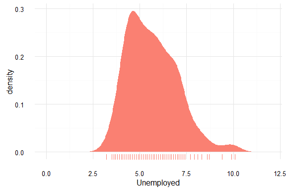

```r
library(ggplot2)

ggplot(data = abs2011,
       aes(x = Unemployed)) +
  geom_density(fill = "salmon",
               bw = "SJ",
               colour = NA) +
  geom_rug(colour = "salmon") +
  theme_minimal() +
  xlim(0, 12)
```

## Unemployment by state

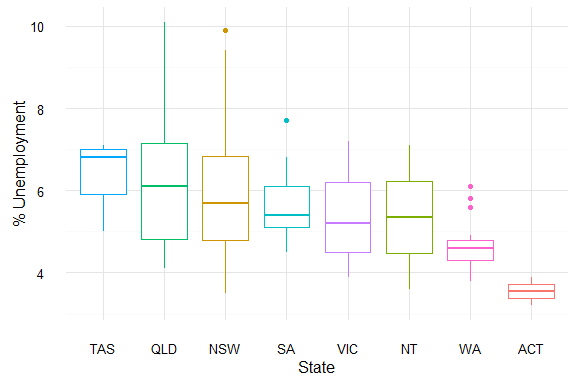

```r
ggplot(data = abs2011,
       aes(x = reorder(State, -Unemployed),
           y = Unemployed,
           colour = State)) +
  geom_boxplot() +
  labs(x = "State",
       y = "% Unemployment") +
  theme_minimal() +
  theme(legend.position = "none")
```

## Age

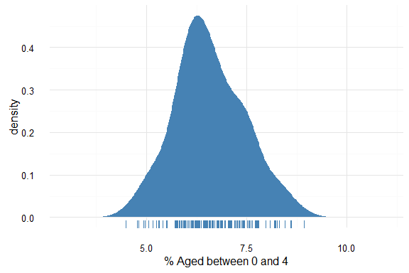

```r
ggplot(data = abs2011,
       aes(x = Age00_04)) +
   geom_density(fill = "steelblue",
               bw = "SJ",
               colour = NA) +
  xlim(3,11) +
  geom_rug(colour = "steelblue") +
  theme_minimal() +
  labs(x = "% Aged between 0 and 4")
```

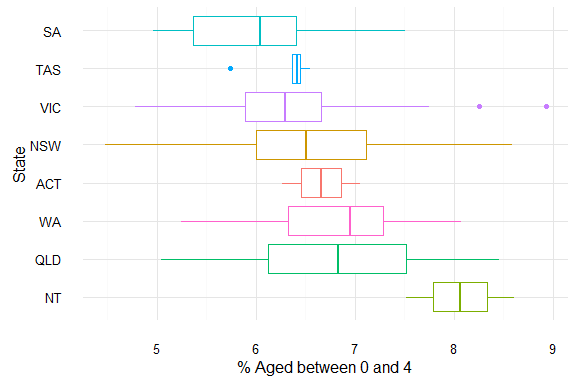

```r
ggplot(data = abs2011,
       aes(x = reorder(State, -Age00_04),
           y = Age00_04,
           colour = State)) +
  geom_boxplot() +
  theme_minimal() +
  labs(x = "State",
       y = "% Aged between 0 and 4") +
  theme(legend.position = "none") +
  coord_flip()
```

However, there are many age groups. To look at all of them at once, we can gather them into a dataframe ready for plotting using `tidyr`.

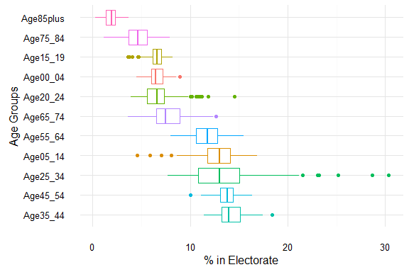

```r
library(tidyr)

abs2011 %>%
  select(starts_with("Age"),
         Electorate) %>%
  gather(key = "Age",
         value = "Percent_in_electorate",
         -Electorate) %>%
  ggplot(data = .,
         aes(x = reorder(Age, - Percent_in_electorate),
             y = Percent_in_electorate,
             colour = Age)) +
  geom_boxplot() +
  coord_flip() +
  theme_minimal() +
  theme(legend.position = "none") +
  labs(x = "Age Groups",
       y = "% in Electorate")
```

## Income

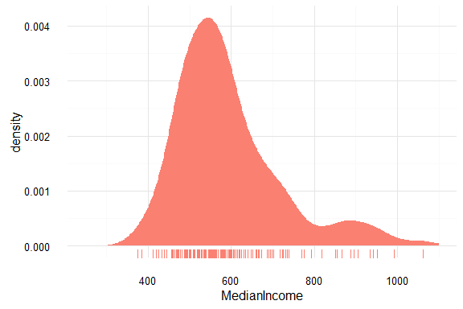

```r
ggplot(data = abs2011,
       aes(x = MedianIncome)) +
  geom_density(fill = "salmon",
               bw = "SJ",
               colour = NA) +
  xlim(250,1100) +
  geom_rug(colour = "salmon") +
  theme_minimal()
```

## Income by State

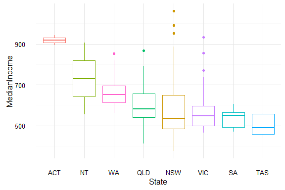

```r
ggplot(data = abs2011,
       aes(x = reorder(State, -MedianIncome),
           y = MedianIncome,
           colour = State)) +
  geom_boxplot() +
  theme_minimal() +
  theme(legend.position = "none") +
  labs(x = "State")
```

If you’re intersted in getting a sense of the distribution of the data, you can add in the points to get a bit more of a sense on the distribution.

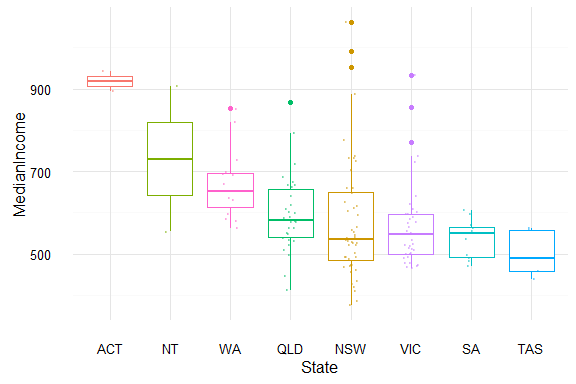

```r
ggplot(data = abs2011,
       aes(x = reorder(State, -MedianIncome),
           y = MedianIncome,
           colour = State)) +
  geom_boxplot() +
  geom_jitter(alpha = 0.35,
              size = 0.5,
              width = 0.3) +
  theme_minimal() +
  theme(legend.position = "none") +
  labs(x = "State")
```

## Education

##### Bachelor

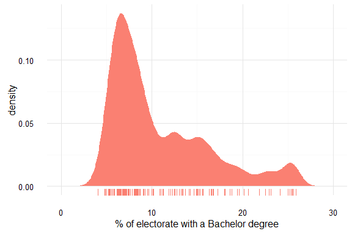

```r
ggplot(data = abs2011,
       aes(x = Bachelor)) +
  geom_density(fill = "salmon",
               bw = "SJ",
               colour = NA) +
  geom_rug(colour = "salmon") +
  theme_minimal() +
  labs(x = "% of electorate with a Bachelor degree") +
  xlim(0, 30)
```

##### Bachelor by state

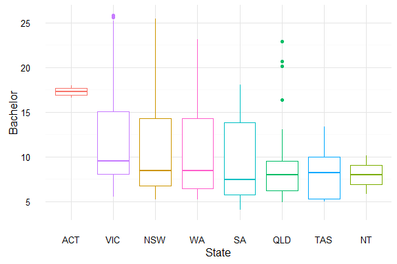

```r
ggplot(data = abs2011,
       aes(x = reorder(State, -Bachelor),
           y = Bachelor,
           colour = State)) +
  geom_boxplot() +
  theme_minimal() +
  labs(x = "State") +
  theme(legend.position = "none")
```

##### Bachelor and income

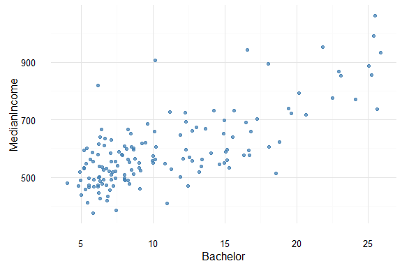

```r
ggplot(data = abs2011,
       aes(x = Bachelor,
           y = MedianIncome)) +
  geom_point(colour = "steelblue",
             alpha = 0.75) +
  theme_minimal()
```

## Postgraduate

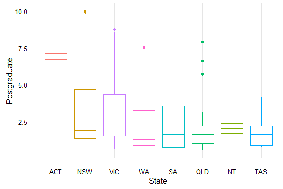

```r
ggplot(data = abs2011,
       aes(x = reorder(State, -Postgraduate),
           y = Postgraduate,
           colour = State)) +
  geom_boxplot() +
  theme_minimal() +
  labs(x = "State") +
  theme(legend.position = "none")
```

##### Postgraduate and income

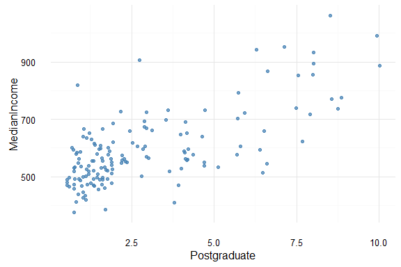

```r
ggplot(data = abs2011,
       aes(x = Postgraduate,
           y = MedianIncome)) +
  geom_point(colour = "steelblue",
             alpha = 0.75) +
  theme_minimal()
```

##### Comparing income across Bachelors and postgraduate

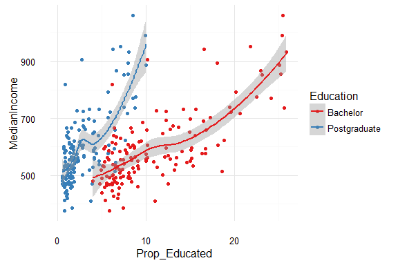

```r
abs2011 %>%
  select(Postgraduate,
         Bachelor,
         MedianIncome) %>%
  gather(key = "Education",
         value = "Prop_Educated",
         -MedianIncome) %>%
ggplot(data = ,
       aes(x = Prop_Educated,
           y = MedianIncome,
           colour = Education)) +
  geom_point() +
  geom_smooth() +
  theme_minimal() +
  scale_color_brewer(type = "qual", palette = "Set1")
```

```r
  # theme(legend.position = "bottom",
  #       legend.direction = "vertical")
```

## Religion

Let’s look at all of the religions

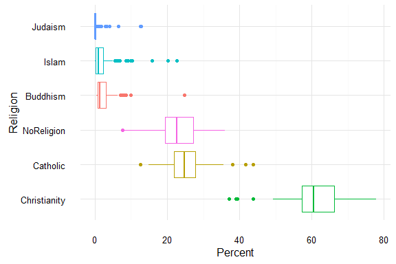

```r
abs2011 %>%
  select(Christianity,
         Catholic,
         Buddhism,
         Islam,
         Judaism,
         NoReligion) %>%
  gather(key = "ReligionType",
         value = "Percent") %>%
  ggplot(data = .,
         aes(x = reorder(ReligionType, -Percent),
             y = Percent,
             colour = ReligionType)) +
  geom_boxplot() +
  theme_minimal() +
  theme(legend.position = "none") +
  coord_flip() +
  labs(x = "Religion")
```

##### Christianity by State

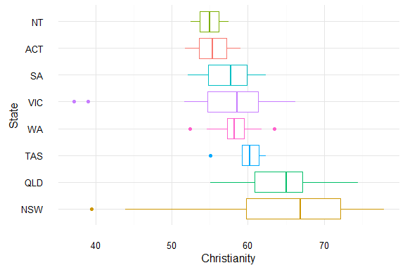

```r
ggplot(data = abs2011,
       aes(x = reorder(State, -Christianity),
           y = Christianity,
           colour = State)) +
  geom_boxplot() +
  theme_minimal() +
  theme(legend.position = "none") +
  coord_flip() +
  labs(x = "State")
```

## Internet

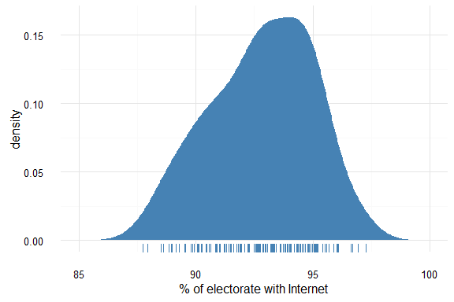

```r
ggplot(data = abs2011,
       aes(x = Internet)) +
  geom_density(fill = "steelblue",
               bw = "SJ",
               colour = NA) +
  geom_rug(colour = "steelblue") +
  theme_minimal() +
  labs(x = "% of electorate with Internet") +
  xlim(85, 100)
```

## Internet by state

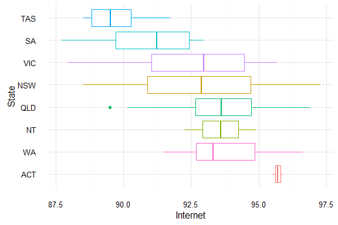

```r
ggplot(data = abs2011,
       aes(x = reorder(State, -Internet),
           y = Internet,
           colour = State)) +
  geom_boxplot() +
  theme_minimal() +
  theme(legend.position = "none") +
  coord_flip() +
  labs(x = "State")
```